[figure not shown]

## Proyecto 02

#### **Estudiante:** Merian Herrera Fuentes

```r
library("FactoMineR")
library("corrplot")
library("ggcorrplot")
library("corrr")
library("rattle")
library("fmsb")
library("ggmap")
library("mapproj")
library("factoextra")
```

#### **I Parte: Algoritmo de recomendación**

**1. [20 puntos] Se le pidió a un grupo de 100 clientes que compraron el mismo producto o productos similares en la tienda de AMAZON, que evaluaran el servicio recibido desde diferentes aspectos. El archivo EjemploAlgoritmosRecomendacion.csv muestra los promedios de la evaluación dada por los clientes en relación a las variables que se pueden apreciar en el encabezado de la tabla. Para este dataset, realice lo siguiente:**

**a) Cargue el dataset EjemploAlgoritmosRecomendacion.csv, verifique que la lectura de los datos es correcta.**

```r
clientes <- read.csv("EjemploAlgoritmosRecomendacion.csv", sep = ";", dec = ",", header = T,row.names = 1)
head(clientes)
```

```
        Velocidad.Entrega Precio Durabilidad Imagen.Producto Valor.Educativo Servicio.Retorno
Adam                 2.05   0.30        3.45            2.35             2.4              2.3
Anna                 0.90   1.50        3.15            3.30             2.5              4.0
Bernard              1.70   2.60        2.85            3.00             4.3              2.7
Edward               1.35   0.50        3.55            2.95             1.8              2.3
Emilia               3.00   0.45        4.80            3.90             3.4              4.6
Fabian               0.95   1.65        3.95            2.40             2.6              1.9
        Tamano.Paquete Calidad.Producto Numero.Estrellas
Adam              2.60             2.10              1.7
Anna              4.20             2.15              2.8
Bernard           4.10             2.60              3.3
Edward            3.90             1.95              1.7
Emilia            2.25             3.40              4.3
Fabian            4.85             2.20              3.0
```

**b) A manera de diagnóstico, haga una inspección de los datos presentes en el dataset y describa las variables presentes, tipos de variables, si hay datos nulos.**

```r
#str(clientes)
sapply(clientes, typeof)
```

```
Velocidad.Entrega            Precio       Durabilidad   Imagen.Producto   Valor.Educativo
         "double"          "double"          "double"          "double"          "double"
 Servicio.Retorno    Tamano.Paquete  Calidad.Producto  Numero.Estrellas
         "double"          "double"          "double"          "double"
```

**c) Determine si existen correlaciones importantes entre las variables del dataset, utilizando alguno de los gráficos o la matriz de correlaciones vistos en clases (si desea, puede usar otra herramienta de su preferencia). Recordemos que para aplicar un ACP, es importante que existan correlaciones entre las variables.**  
A continuación se muestran las correlaciones numericas para el dataset clientes:

```r
# Para ver las correlaciones numéricas
correlaciones_numericas <- round(cor(clientes), 2)
correlaciones_numericas
```

```
                  Velocidad.Entrega Precio Durabilidad Imagen.Producto Valor.Educativo Servicio.Retorno
Velocidad.Entrega              1.00  -0.35        0.51            0.05            0.61             0.08
Precio                        -0.35   1.00       -0.49            0.27            0.51             0.19
Durabilidad                    0.51  -0.49        1.00           -0.12            0.07            -0.03
Imagen.Producto                0.05   0.27       -0.12            1.00            0.30             0.79
Valor.Educativo                0.61   0.51        0.07            0.30            1.00             0.24
Servicio.Retorno               0.08   0.19       -0.03            0.79            0.24             1.00
Tamano.Paquete                -0.48   0.47       -0.45            0.20           -0.06             0.18
Calidad.Producto               0.65   0.03        0.52            0.48            0.63             0.34
Numero.Estrellas               0.68   0.08        0.56            0.22            0.70             0.26
                  Tamano.Paquete Calidad.Producto Numero.Estrellas
Velocidad.Entrega          -0.48             0.65             0.68
Precio                      0.47             0.03             0.08
Durabilidad                -0.45             0.52             0.56
Imagen.Producto             0.20             0.48             0.22
Valor.Educativo            -0.06             0.63             0.70
Servicio.Retorno            0.18             0.34             0.26
Tamano.Paquete              1.00            -0.28            -0.19
Calidad.Producto           -0.28             1.00             0.71
Numero.Estrellas           -0.19             0.71             1.00
```

```r
corrplot(correlaciones_numericas)
```

[output not shown]

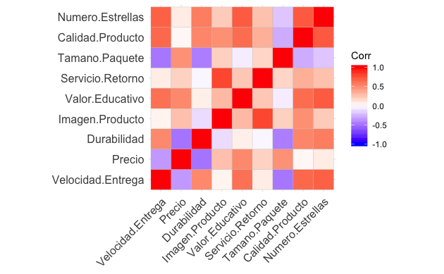

```r
ggcorrplot(correlaciones_numericas)
```

> Las correlaciones **positivas** más fuertes que se observan son:  
> - **Imagen del producto** con **Servicio de Retorno**  
> - **Número de estrellas** con **valor educativo**  
> - **Número de estrellas** con **velocidad de entrega**  
> - **Velocidad de entrega** con **calidad del producto**  
> Las correlaciones **negativas** más fuertes que se observan son:  
> - **Precio** con **durabilidad**  
> - **Tamaño del paquete** con **velocidad de entrega**  
> - **Tamaño del paquete** con **durabilidad**

**d) Realice un ACP usando el paquete FactoMiner, creando el plano principal y el círculo de correlaciones. Superponga ambos gráficos e identifique la cantidad de clústeres que considere apropiado. Haga un análisis descriptivo de cada clúster, indique si hay variables correlacionadas y el tipo de correlación entre estas.**

```r
pca_clientes <- PCA(clientes, scale.unit=TRUE, ncp=5, graph = FALSE)
plot(pca_clientes, axes=c(1, 2), choix="ind", col.ind="purple",new.plot=TRUE)
```

[output not shown]

```r
plot(pca_clientes, axes=c(1, 2), choix="var", col.var="blue",new.plot=TRUE)
```

[output not shown]

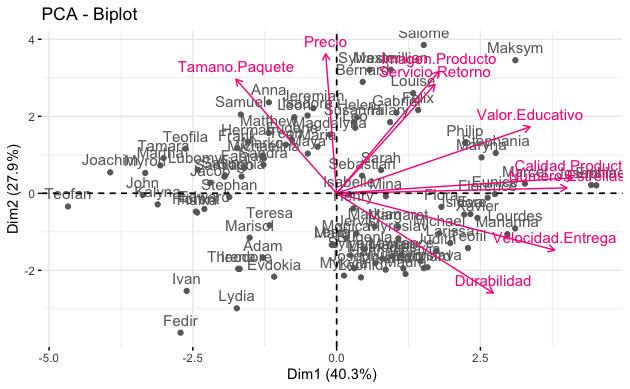

```r
fviz_pca_biplot(pca_clientes, repel = FALSE,
                col.var = "#fc078a", # Variables color
                col.ind = "#696969"  # Individuals color
                )
```

> Se pueden observar **2 clústeres** bien marcados, cada uno de estos por una correlacion negativa entre el tamaño del paquete y la durabilidad. Podriamos decir que cada grupo de personas representados por un cluster opinaron de manera muy similar en las evaluaciones.  
> **Clúster 01:** En este primer cluster podemos observar al grupo de personas que valora de una manera mas alta el tamano del paquete, de este primer cluster tambien podemos deducir que este grupo de personas valora de una manera positiva variables como el precio, imagen del producto y servicio de retorno. Tambien se observa una correlacion positiva muy fuerte entre la imagen del producto y el servicio de retorno.  
> **Clúster 02:** En este segundo grupo de personas podemos encontrar a quienes valoran de una manera mas positiva la durabilidad del producto, estas personas tambien le dan mas importancia a la velocidad de entrega y calidad del producto, Se observa una correlacion positiva fuerte entre calidad del producto y numero de estrellas, lo que nos iindica que a mayor calidad del producto mayor numero de estrellas.

**e) Repita el ejercicio anterior usando el paquete FactoMineR, elimine de los gráficos los individuos con $cos^{2} (\theta)$ $\le 0.2$ y las variables $cos^{2} (\theta)$ $\le 0.55$ y vuelva a crear el plano principal y el círculo de correlaciones. ¿Cuáles individuos quedaron mal representados?, ¿cuáles variables quedaron mal representadas?**

Sugerencia: Puede usar el código del documento o cualquiera de su preferencia:

**¿Cuáles individuos quedaron mal representados?**

```r
# El coseno cuadrado se calcula sumando los valores de las dos dimensiones por individuo o por variable (puede revisar la presentación, en las diapositivas finales se explica como se calcula este dato

# Se parte del hecho de que ya se tiene el modelo de ACP, que hemos llamado para efectos del ejemplo pca_clientes, de ahí se extrae los cosenos cuadrados de los individuos. Para el caso de las variables, debe cambiar la instrucción pca_datos$ind$cos2 por pca_clientes$var$cos2
cos2.ind<-(pca_clientes$ind$cos2[,1] + pca_clientes$ind$cos2[,2])

individuos_malrepresentados <- NULL

for (i in 1 : nrow(clientes)) {
  ifelse(cos2.ind [i] <= 0.2, individuos_malrepresentados <- rbind(individuos_malrepresentados, i), NA)
}

cos2.ind[individuos_malrepresentados]
```

[output not shown]

```r
#plot(pca_clientes, axes=c(1, 2), choix="ind", col.ind="red",new.plot=TRUE, select="cos2 0.2")
```

```r
#res.pca <- prcomp(clientes, scale = TRUE)
fviz_pca_ind(pca_clientes,
             col.ind = "cos2", # Color by the quality of representation
             gradient.cols = c("#00AFBB", "#E7B800", "#fc078a"),
             repel = FALSE     # Avoid text overlapping
             )
```

[output not shown]

**¿Cuáles variables quedaron mal representadas?**

```r
cos2.var<-(pca_clientes$var$cos2[,1] + pca_clientes$var$cos2[,2])

variables_malrepresentadas <- NULL
for (i in 1 : ncol(clientes)) {
  header <- names(cos2.var[i])[1]
  value <- cos2.ind[i]
 ifelse(value <= 0.55, variables_malrepresentadas <- cbind(matrix(c(header, value), 2, 1, TRUE), variables_malrepresentadas), NA)
}
variables_malrepresentadas
```

[output not shown]

```r
# plot(pca_clientes, axes=c(1, 2), choix="var", col.var="blue",new.plot=TRUE, select="cos2 0.55")
```

```r
fviz_pca_var(pca_clientes,
             col.var = "cos2", # Color by contributions to the PC
             gradient.cols = c("#00AFBB", "#E7B800", "#fc078a"),
             repel = TRUE     # Avoid text overlapping
             )
```

[output not shown]

**f) Realice un gráfico radar (araña) usando 3 clústeres e interprete cada uno de los clústeres.**

```r
modelo <- hclust(dist(clientes),method= "ward")
```

```
The "ward" method has been renamed to "ward.D"; note new "ward.D2"
```

```r
centros<-centers.hclust(clientes,modelo,nclust=3,use.median=FALSE)
centros
```

```
     Velocidad.Entrega    Precio Durabilidad Imagen.Producto Valor.Educativo Servicio.Retorno
[1,]          1.262791 1.1511628    3.503488        2.496512        2.358140         2.516279
[2,]          1.700000 1.7090909    3.843182        3.006818        3.390909         3.040909
[3,]          2.401429 0.8885714    4.557143        2.540000        3.302857         2.611429
     Tamano.Paquete Calidad.Producto Numero.Estrellas
[1,]       3.748837         2.019767         2.288372
[2,]       3.979545         2.590909         3.472727
[3,]       2.851429         2.705714         3.891429
```

```r
rownames(centros)<-c("Cluster 1","Cluster 2","Cluster 3")
centros<-as.data.frame(centros)
maximos<-apply(centros,2,max)
minimos<-apply(centros,2,min)
centros<-rbind(minimos,centros)
centros<-rbind(maximos,centros)
centros
```

```
          Velocidad.Entrega    Precio Durabilidad Imagen.Producto Valor.Educativo Servicio.Retorno
1                  2.401429 1.7090909    4.557143        3.006818        3.390909         3.040909
11                 1.262791 0.8885714    3.503488        2.496512        2.358140         2.516279
Cluster 1          1.262791 1.1511628    3.503488        2.496512        2.358140         2.516279
Cluster 2          1.700000 1.7090909    3.843182        3.006818        3.390909         3.040909
Cluster 3          2.401429 0.8885714    4.557143        2.540000        3.302857         2.611429
          Tamano.Paquete Calidad.Producto Numero.Estrellas
1               3.979545         2.705714         3.891429
11              2.851429         2.019767         2.288372
Cluster 1       3.748837         2.019767         2.288372
Cluster 2       3.979545         2.590909         3.472727
Cluster 3       2.851429         2.705714         3.891429
```

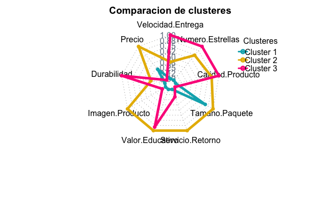

```r
radarchart(centros,maxmin=TRUE,axistype=4,axislabcol="slategray4",
           centerzero=FALSE,seg=8,cglcol="gray67",
           pcol=c("#00AFBB", "#E7B800", "#fc078a"),
           plty=1,
           plwd=5,
           title="Comparacion de clusteres")
legenda <-legend(1.5,1, legend=c("Cluster 1","Cluster 2","Cluster 3"),
                 seg.len=-1.4,
                 title="Clusteres",
                 pch=21,
                 bty="n" ,lwd=3, y.intersp=1, horiz=FALSE,
                 col=c("#00AFBB", "#E7B800", "#fc078a"))
```

> **Cluster 1:** En el cluster 1 podemos ber donde la variable que tiene mas importancia para esos individuos es la del tamaño del paquete y como segunda variable mas importante es la del precio, las demas variables tienen un valor muy bajo, por lo tanto los individuos que pertenecen al cluster 1 les han dado poca importancia.  
> **Cluster 2:** En este cluster podemos orservar como las variables Precio, Imagen del producto. Valor educativo, Servicio de retorno y tamaño del paquete han sido evaluadas de manera alta por el grupo de individuos que pertenecen a este cluster.  
> **Cluster 3:** Podemos apreciar como las variables Numero de estrellas, calidad del producto, valor educativo y durabilidad son las que fueron evaluadas con las calificaciones mas altas por los individuos de esete cluster

**g) Suponga que se trabajaron los datos con 3 clústeres, como se muestra en el plano principal siguiente:**

```r
# pca_alg.hcpc <- HCPC(pca_clientes, nb.clust=-1, min=2, max=3)
# plot(pca_alg.hcpc, axes = 3:4)
```

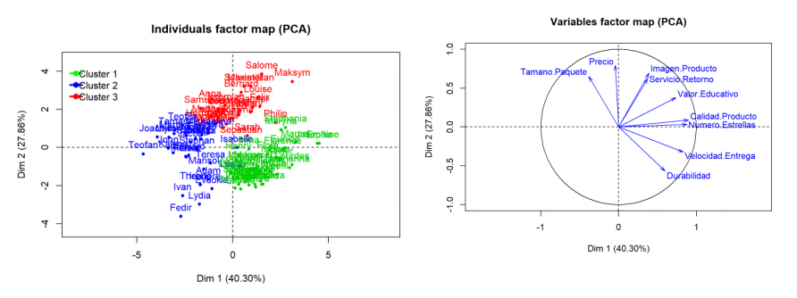

Partiendo del hecho de que todos los individuos compraron, ya sea el mismo producto o similares, pero, cada uno tuvo una experiencia de compra diferente que pudo ser mejor o peor en los diferentes rubros de la evaluación,

• ¿Qué productos recomendaría a Salome?

> Salome se encuentra representado en el cluster 3, donde tambien se encuentran representados otros individuos que le dan mayor valor a las mismas variables que Salome, por lo tanto, se recomienda a Salome comprar los mismos productos adquiridos por personas dentro de este cluster como: Maksym, Louise, Philip…

**• ¿Qué productos recomendaría a Stephania?**

> A Stephania la vemos representada en el cluster 1, donde tambien vemos representados a individuos como Maryna, Eunice y Marcel Se recomienda a Stephania adquirir productos que han comprado algunos de los individuos mencionados previamente o productos adquiridos por cualquiera de los individuos representados en el cluster 1.

**• ¿Qué productos recomendaría a Lydia?**

> Lydia por su parte esta representada dentro del cluster 2, dentro de este cluster tambien vemos representados a Ivan, Fedir, Evdokia… Al igual que los individuos representados en los clusters 1 y 3, se recomienda a Lydia comprar productos que han sido adquiridos por los individuos representados en el cluster que la representa, en este caso el cluster 2.

**Es decir, los mismos productos que compró cuál otro cliente.**

#### **II PARTE: resuelva la siguiente situación**

**1. [10 puntos] Considérese tabla datos ConsumoEuropa.csv que contiene una estimación del consumo promedio de proteínas, en gramos, por persona y por día, en Europa, datos del año 1981 (Está en el aula virtual con el nombre).**

```r
consumo <- read.csv("ConsumoEuropa.csv", sep = ";", dec = ",", header = T,row.names = 1)
#print(dim(consumo))
head(consumo, 50)
```

```
               CarneAnimal CarneCerdo Huevos Leche CarnePescado Cereales Almidon Semillas Frutas
Albania               10.1        1.4    0.5   8.9          0.2     42.3     0.6      5.5    1.7
Austria                8.9       14.0    4.3  19.9          2.1     28.0     3.6      1.3    4.3
Belgica               13.5        9.3    4.1  17.5          4.5     26.6     5.7      2.1    4.0
Bulgaria               7.8        6.0    1.6   8.3          1.2     56.7     1.1      3.7    4.2
Checoslovaquia         9.7       11.4    2.8  12.5          2.0     34.3     5.0      1.1    4.0
Dinamarca             10.6       10.8    3.7  25.0          9.9     21.9     4.8      0.7    2.4
Alemania Or.           8.4       11.6    3.7  11.1          5.4     24.6     6.5      0.8    3.6
Finlandia              9.5        4.9    2.7  33.7          5.8     26.3     5.1      1.0    1.4
Francia               18.0        9.9    3.3  19.5          5.7     28.1     4.8      2.4    6.5
Grecia                10.2        3.0    2.8  17.6          5.9     41.7     2.2      7.8    6.5
Hungria                5.3       12.4    2.9   9.7          0.3     40.1     4.0      5.4    4.2
Irlanda               13.9       10.0    4.7  25.8          2.2     24.0     6.2      1.6    2.9
Italia                 9.0        5.1    2.9  13.7          3.4     36.8     2.1      4.3    6.7
Holanda                9.5       13.6    3.6  23.4          2.5     22.4     4.2      1.8    3.7
Noruega                9.4        4.7    2.7   3.3          9.7     23.0     4.6      1.6    2.7
Polonia                6.9       10.2    2.7  19.3          3.0     36.1     5.9      2.0    6.6
Portugal               6.2        3.7    1.1   4.9         14.2     27.0     5.9      4.7    7.9
Rumania                6.2        6.3    1.5  11.1          1.0     49.6     3.1      5.3    2.8
Espana                 7.1        3.4    3.1   8.6          7.0     29.2     5.7      5.9    7.2
Suecia                 9.9        7.8    3.5  24.7          7.5     19.5     3.7      1.4    2.0
Suiza                 13.1       10.1    3.1  23.8          2.3     25.6     2.8      2.4    4.9
Reino Unido           17.4        5.7    4.7  20.6          4.3     24.3     4.7      3.4    3.3
URSS                   9.3        4.6    2.1  16.6          3.0     43.6     6.4      3.4    2.9
Alemania Occ.         11.4       12.5    4.1  18.8          3.4     18.6     5.2      1.5    3.8
Yugoslavia             4.4        5.0    1.2   9.5          0.6     55.9     3.0      5.7    3.2
```

**a. Usando FactoMineR efectúe un ACP para esta tabla de datos.**

```r
pca_consumo <- PCA(consumo, scale.unit=TRUE, ncp=5, graph = FALSE)
typeof(pca_consumo)
print(pca_consumo)
```

[output not shown]

```r
#pca_consumo$var$coord
pca_consumo$ind
```

[output not shown]

**b. Grafique el plano principal y el círculo de correlaciones, luego compare este Plano Principal con el mapa de Europa ¿Qué conclusiones puede sacar?**

Considere que podría recortar alguno de estos gráficos, hacer rotaciones y es necesario buscar un mapa de Europa, de preferencia un mapa político.

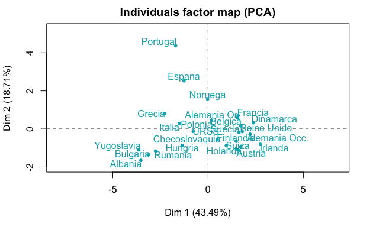

```r
plot(pca_consumo, axes=c(1, 2), choix="ind", col.ind="#00AFBB",new.plot=TRUE)
```

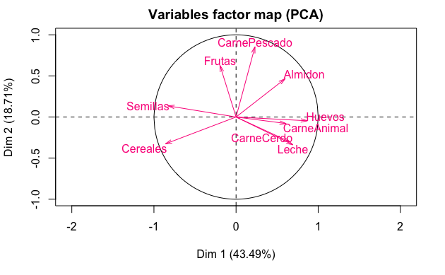

```r
plot(pca_consumo, axes=c(1, 2), choix="var", col.var="#fc078a",new.plot=TRUE)
```

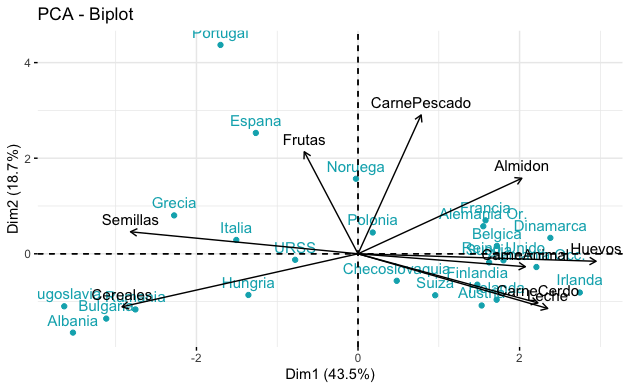

```r
fviz_pca_biplot(pca_consumo, repel = FALSE,
                col.var = "#000000", # Variables color
                col.ind = "#00AFBB"  # Individuals color
                )
```

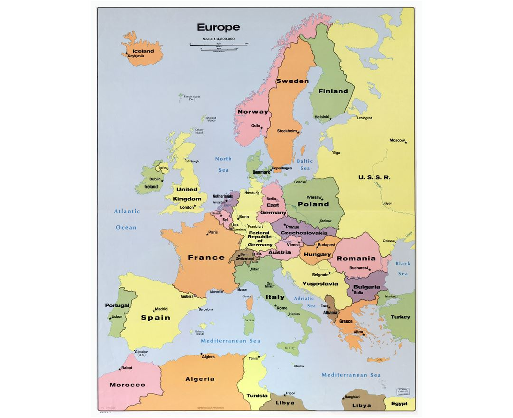